# Clustering tweets by TF-IDF profile

Clustering the training tweets by their TF-IDF vector alone, no sentiment label involved, then checking how well the clusters line up with the real positive/negative split afterward.

```python
import pickle
import numpy as np
import pandas as pd
import matplotlib.pyplot as plt

with open('data/model_matrix.pkl', 'rb') as f:
    d = pickle.load(f)
X_train, y_train = d['X_train'], d['y_train']
X_train.shape
```

```
(20000, 5000)
```

```python
from sklearn.decomposition import TruncatedSVD
from sklearn.cluster import KMeans
from sklearn.mixture import GaussianMixture
from sklearn.metrics import silhouette_score, adjusted_rand_score

svd = TruncatedSVD(n_components = 50, random_state = 42)
X_svd = svd.fit_transform(X_train)
print(f'50 SVD components explain {svd.explained_variance_ratio_.sum():.1%} of variance')
```

```
50 SVD components explain 14.1% of variance
```

```python
K = 2
kmeans = KMeans(n_clusters = K, n_init = 10, random_state = 42)
kmeans_labels = kmeans.fit_predict(X_svd)

gmm = GaussianMixture(n_components = K, covariance_type = 'diag', random_state = 42, n_init = 3)
gmm_labels = gmm.fit_predict(X_svd)

print('KMeans silhouette:', silhouette_score(X_svd, kmeans_labels))
print('KMeans vs true sentiment (ARI):', adjusted_rand_score(y_train, kmeans_labels))
print('GMM vs true sentiment (ARI):', adjusted_rand_score(y_train, gmm_labels))
```

```
KMeans silhouette: 0.0752026664612219
KMeans vs true sentiment (ARI): 0.008403033766935828
GMM vs true sentiment (ARI): 0.0013575501571860354
```

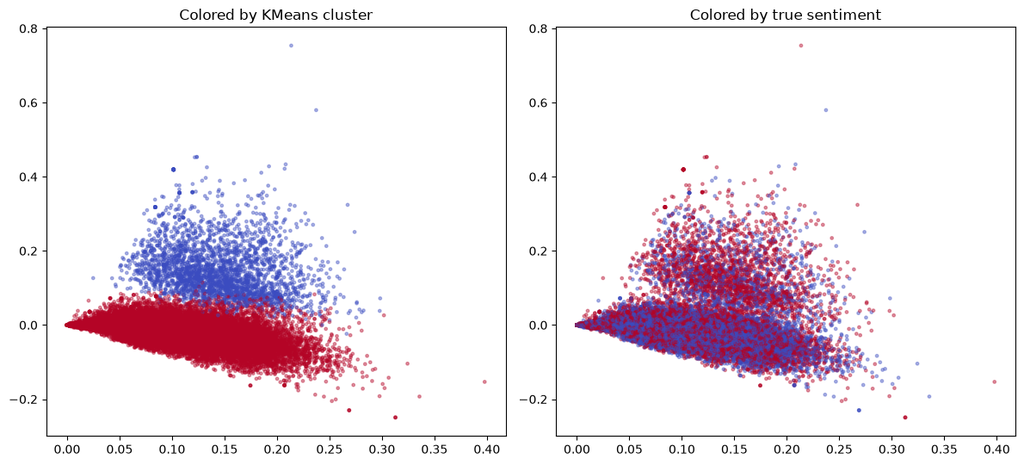

```python
fig, axes = plt.subplots(1, 2, figsize = (12, 5.5))
sc0 = axes[0].scatter(X_svd[:, 0], X_svd[:, 1], c = kmeans_labels, cmap = 'coolwarm', s = 6, alpha = 0.4)
axes[0].set_title('Colored by KMeans cluster')
sc1 = axes[1].scatter(X_svd[:, 0], X_svd[:, 1], c = y_train, cmap = 'coolwarm', s = 6, alpha = 0.4)
axes[1].set_title('Colored by true sentiment')
plt.tight_layout()
plt.savefig('outputs/clustering_svd.png', dpi = 120)
plt.show()
```

Both methods land at essentially zero agreement with the real sentiment labels (adjusted Rand index 0.008 for KMeans, 0.001 for GMM, indistinguishable from chance). This is a genuinely important, honest result, not a failed experiment: TF-IDF captures which *words* co-occur, which mostly reflects what a tweet is *about* (a topic), not how the author *feels* about it. Two tweets can share almost identical vocabulary ("my flight is delayed" vs "my flight got upgraded") while having opposite sentiment, and raw bag-of-words clustering has no way to tell them apart. This is exactly why the supervised models in notebook 03, which get to see the label during training and learn which specific words correlate with which sentiment, do so much better (76-79% accuracy) than any unsupervised grouping of the same features.